# Regression Test

Obaid

2021-02-19

```yaml
output:
  prettydoc::html_pretty:
    theme: architect
    highlight: github
```

# Configuration

List of the packages used and access to the data:

```r
# the package {prettydoc} is used in the YAML (not loaded in the code chunks)
# libraries --------------------------------------------------------------------
library(tidyverse)
library(here)
library(scales)
library(knitr)
library(kableExtra)
library(modelr)

# data -------------------------------------------------------------------------
daftdb <- here("data/daftdb.rds") %>% read_rds()
```

I have taken your work as a starting point for the inferential analysis.

The data consist in 37487 observations of 973 unique properties located in North Dublin Areas, Ireland, listed on the website [daft.ie](https://www.daft.ie/) between 2020-03-09 which corresponds to the beginning of the first Irish lockdown and 2020-06-02.

The objective of this project is to evaluate the changes in prices during this period.

# Cleaning and Parsing

First let’s have a look at the data. There are many functions to have a nice first insight, the most basic one is `str()` from {base}, I always use it but people in the tidyverse like using `glimpse()` from {tibble}. Why not using this last one for once

```r
glimpse(daftdb)
```

```
## Rows: 37,487
## Columns: 8
## $ index     <dbl> 0, 1, 2, 3, 4, 5, 6, 7, 8, 9, 10, 11, 12, 13, 14, 15, 16,...
## $ address   <chr> "138 Church Road, East Wall, Dublin 3", "44 Shanglas Road...
## $ price     <chr> "\u0080350,000", "\u0080445,000", "\u0080595,000", "\u008...
## $ bathroom  <dbl> 1, 2, 2, 1, 1, 3, 1, 1, 3, 2, 2, 2, 5, 1, 1, 1, 1, 2, 2, ...
## $ bedroom   <dbl> 3, 3, 4, 3, 4, 4, 2, 3, 4, 3, 4, 4, 6, 4, 2, 3, 3, 3, 4, ...
## $ structure <chr> "Terraced House", "Semi-Detached House", "Terraced House"...
## $ date      <date> 2020-03-09, 2020-03-09, 2020-03-09, 2020-03-09, 2020-03-...
## $ weblink   <chr> "/dublin/houses-for-sale/east-wall/138-church-road-east-w...
```

There are many things that we can see from here:

1. We want an analysis for each Dublin Area but there is no column so we will have to extract the last bit of the address (*e.g.,* Dublin 1, Dublin 2, …)
2. The price is a character string variable, we need to extract the numbers to convert it as numeric values
3. The date is already in date type! no need to convert it actually

## 1. Extracting Area

Many thanks to some of you to provide the solution using regex. Regex is one of the most difficult thing in R (and in several other languages) but it’s also one of the most useful. To extract the area, it is possible to search for “Dublin” in the string and to get all the numbers following:

```r
daftdb <- daftdb %>%
  mutate(
    area = str_extract(address, "Dublin [0-9]+")
  )

daftdb %>%
  select(address, area) %>%
  slice_sample(n = 5)
```

```
## # A tibble: 5 x 2
##   address                                                      area
##   <chr>                                                        <chr>
## 1 Grace Park House, 8 Grace Park Gardens, Drumcondra, Dublin 3 Dublin 3
## 2 102 Mount Prospect Avenue, Clontarf, Dublin 3                Dublin 3
## 3 28 Grace O Malley Road, Howth, Co. Dublin                    <NA>
## 4 54 Kirwan Street Cottages, Stoneybatter, Dublin 7            Dublin 7
## 5 3 Grace Park Grove, Grace Park Wood, Drumcondra, Dublin 3    Dublin 3
```

I was thinking of extracting only the last character(s) of the address, it could work be it’s not as elegant.

We could also imagine a `separate()` from {tidyr} using “Dublin” as separator but it will be less efficient.

## 2. Parsing Price

Here is another classic but deadly problem, the values of price are characters with the symbol euro, some values have characters before the actual price “AMC” and some have “Price On Application” instead of a value.

Even if it would be more complicated to use a regex here, it would still do. However, after a couple of minutes googling, I found the function `parse_number()` from {readr} that is very promising.

*Modifications*

Parsed area to exact the area code just to investigate its effect

```r
daftdb <- daftdb %>%
  mutate(
    price_parsed = parse_number(price, locale = locale(grouping_mark = ",")),
    area_parsed = parse_number(area, locale = locale(grouping_mark = ",")),

  )

daftdb %>%
  select(price, price_parsed) %>%
  slice_sample(n = 5)
```

```
## # A tibble: 5 x 2
##   price         price_parsed
##   <chr>                <dbl>
## 1 "\x80495,000"       495000
## 2 "\x80330,000"       330000
## 3 "\x80420,000"       420000
## 4 "\x80385,000"       385000
## 5 "\x80350,000"       350000
```

It triggers a lot of warnings due to “Price On Application” which is replaced by NA values but NA values is what we want.

> Note: The temptation to replace NA values by 0 is real but this is a huge mistake to not do. Imagine a series of values 1000, NA, and 2000; its average is 1500. But if you replace NA with 0 the average will be 1000. The higher the numbers, the bigger the mistake.

## 3. Difference Calculation

Now the most important is to check is the price of property changed. Once again there are multiple solutions but I will present the first one that came to me:

*Modifications*

added other values need to investigated such as bedroom, bathroom, price_parse, area and area_parsed

```r
daftdiff <- daftdb %>%
  group_by(address, area) %>%
  summarise(price_diff = max(price_parsed) - min(price_parsed),bathroom,bedroom,price_parsed,area,area_parsed) %>%
  ungroup()

daftdiff %>%
  slice_sample(n = 5)
```

```
## # A tibble: 5 x 7
##   address            area   price_diff bathroom bedroom price_parsed area_parsed
##   <chr>              <chr>       <dbl>    <dbl>   <dbl>        <dbl>       <dbl>
## 1 1A The Orchard, K~ Dubli~          0        2       3       420000           5
## 2 88 Kincora Road, ~ Dubli~          0        4       4       995000           3
## 3 The Pines, Greenf~ Dubli~          0        5       5      1250000          13
## 4 20 St. Donaghs Ro~ Dubli~          0        1       3       300000          13
## 5 275 Kilbarrack Ro~ Dubli~          0        1       3       350000           5
```

# Descriptive Analysis

Each area appears to be very different in term of distribution of prices. The table here below describes each area:

```r
daftdb %>%
  filter(!is.na(area)) %>%
  group_by(area) %>%
  summarise(
    n_property = n_distinct(address),
    price_mean = mean(price_parsed, na.rm = TRUE) %>% dollar(suffix = "", prefix = "€"),
    price_sd = sd(price_parsed, na.rm = TRUE) %>% dollar(suffix = "", prefix = "€")
  ) %>%
  kbl() %>%
  kable_styling(bootstrap_options = "striped", font_size = 10)
```

| area | n_property | price_mean | price_sd |
| --- | --- | --- | --- |
| Dublin 1 | 3 | €1,036,176 | €206,864 |
| Dublin 11 | 163 | €343,955 | €108,306 |
| Dublin 13 | 111 | €669,826 | €595,174 |
| Dublin 15 | 10 | €447,333 | €108,103 |
| Dublin 17 | 9 | €244,752 | €44,639.65 |
| Dublin 3 | 207 | €570,514 | €273,561 |
| Dublin 5 | 157 | €418,293 | €116,792 |
| Dublin 7 | 156 | €419,272 | €130,769 |
| Dublin 9 | 151 | €498,093 | €249,881 |

Dublin 1 has a very high average property price but only has 3 properties. The average price is far lower in the other areas with Dublin 17 having the lowest.

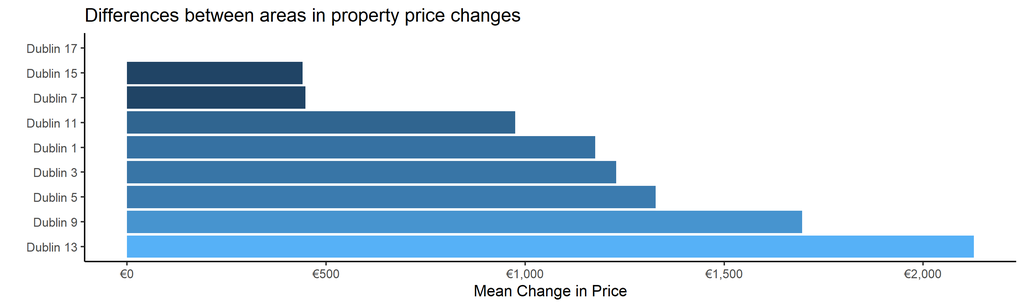

```r
daftdiff %>%
  filter(!is.na(area)) %>%
  group_by(area) %>%
  summarise(price_diff_mean = mean(price_diff, na.rm = TRUE)) %>%
  ggplot(aes(price_diff_mean, reorder(area, desc(price_diff_mean)), fill = price_diff_mean)) +
  geom_col() +
  scale_x_continuous(labels = dollar_format(suffix = "", prefix = "€")) +
  theme_classic() +
  theme(legend.position = "none") +
  labs(
    x = "Mean Change in Price",
    y = "",
    title = "Differences between areas in property price changes"
  )
```

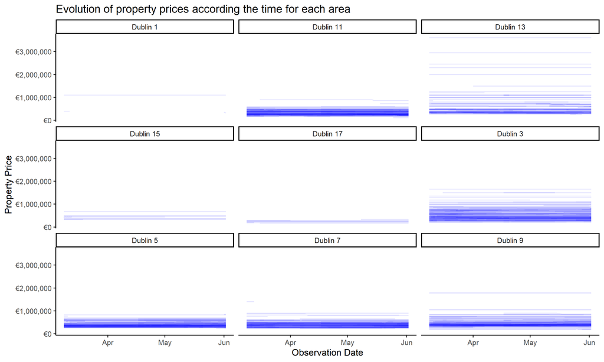

```r
daftdb %>%
  filter(!is.na(area)) %>%
  ggplot(aes(date, price_parsed, group = address)) +
  geom_line(color = "blue", alpha = 0.1) +
  scale_y_continuous(labels = dollar_format(suffix = "", prefix = "€")) +
  facet_wrap(~ area) +
  theme_classic() +
  labs(
    x = "Observation Date",
    y = "Property Price",
    title = "Evolution of property prices according the time for each area"
  )
```

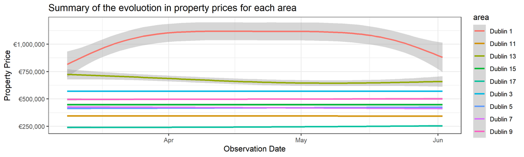

```r
daftdb %>%
  filter(!is.na(area)) %>%
  ggplot(aes(date, price_parsed, color = area)) +
  geom_smooth() +
  scale_y_continuous(labels = dollar_format(suffix = "", prefix = "€")) +
  theme_bw() +
  labs(
    x = "Observation Date",
    y = "Property Price",
    title = "Summary of the evoluotion in property prices for each area"
  )
```

Despite no apparent changes in the prices, it is possible to go further with some inferential analyses to see the relationship between houses characteristics and price.

#Bivaraite Analysis

We will used the modified data to investigate further using a new dataframe `df2` which extracts data from `daftdiff`

```r
df2<- daftdiff %>%
  select(price_diff,price_parsed, bedroom,bathroom,area) %>%
  mutate_at(vars(area),  ~ if_else(is.na(.), "Co. Dublin", .)) %>%
  mutate( bedroom=as.factor(bedroom),bathroom=as.factor(bathroom))


df2 %>%
  slice_sample(n = 5)
```

```
## # A tibble: 5 x 5
##   price_diff price_parsed bedroom bathroom area
##        <dbl>        <dbl> <fct>   <fct>    <chr>
## 1          0       395000 3       2        Dublin 3
## 2          0       445000 3       2        Dublin 9
## 3          0       595000 3       2        Dublin 5
## 4          0      3600000 5       4        Dublin 13
## 5          0       425000 3       3        Dublin 11
```

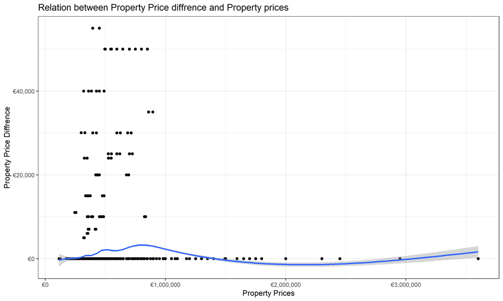

```r
ggplot(df2, aes(y=price_diff, x=price_parsed)) +
  geom_point()+
   geom_smooth() +
  scale_y_continuous(labels = dollar_format(suffix = "", prefix = "€")) +
  scale_x_continuous(labels = dollar_format(suffix = "", prefix = "€"))+
  theme_bw() +
  labs(
    x = "Property Prices",
    y = "Property Price Diffrence",
    title = "Relation between Property Price diffrence and Property prices"
  )
```

If we just observe the properties which observed the price changes.

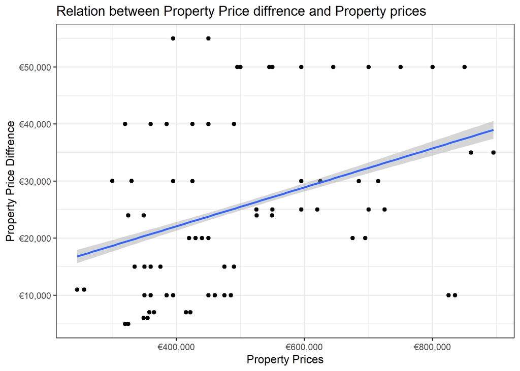

```r
df2%>%
  filter(price_diff!=0)%>%
  ggplot(aes(y=price_diff, x=price_parsed)) +
    geom_point()+
     geom_smooth(method=lm) +
    scale_y_continuous(labels = dollar_format(suffix = "", prefix = "€")) +
    scale_x_continuous(labels = dollar_format(suffix = "", prefix = "€"))+
    theme_bw() +
    labs(
      x = "Property Prices",
      y = "Property Price Diffrence",
      title = "Relation between Property Price diffrence and Property prices"
    )
```

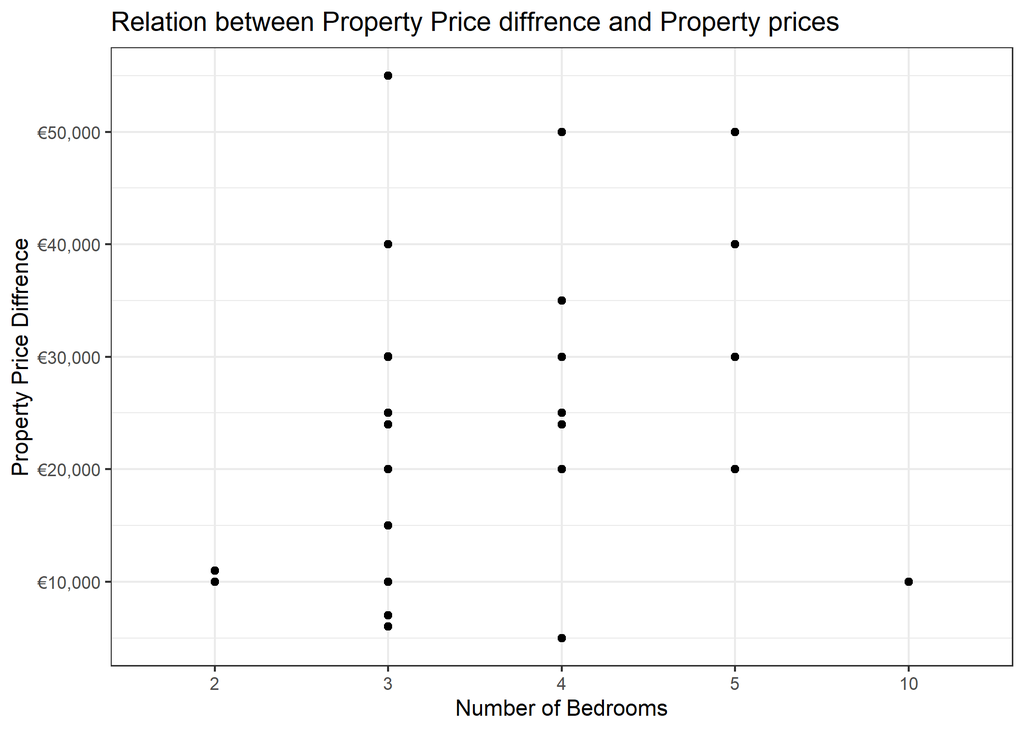

```r
df2%>%
  filter(price_diff!=0)%>%
  ggplot() +
    geom_point(aes(bedroom,price_diff))+
  geom_smooth(aes(y=price_diff, x=bedroom),method=lm) +
  scale_y_continuous(labels = dollar_format(suffix = "", prefix = "€")) +
    theme_bw() +
    labs(
      x = "Number of Bedrooms",
      y = "Property Price Diffrence",
      title = "Relation between Property Price diffrence and Property prices"
    )
```

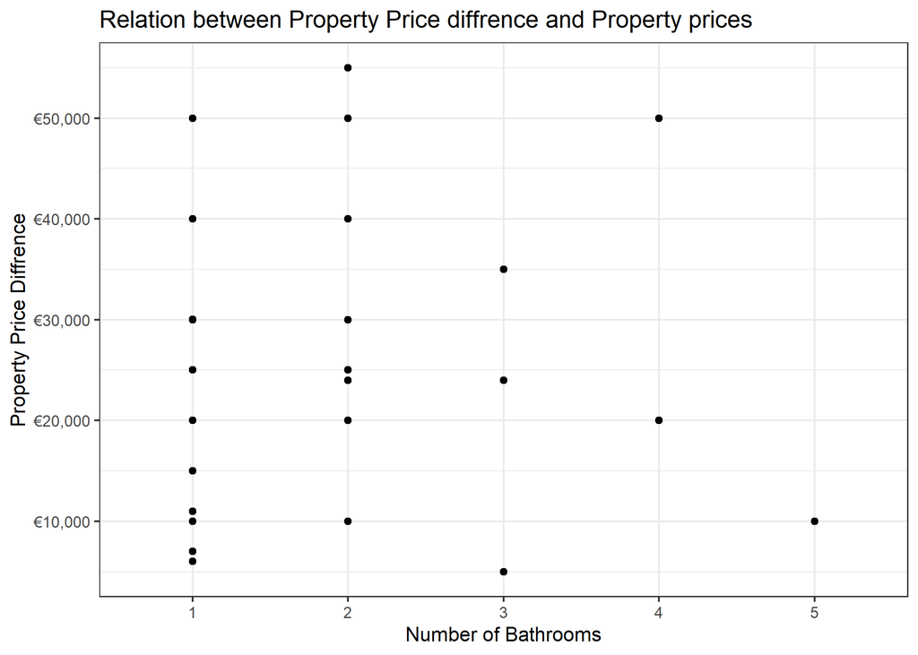

```r
df2%>%
  filter(price_diff!=0)%>%
  ggplot() +
    geom_point(aes(bathroom,price_diff))+
  scale_y_continuous(labels = dollar_format(suffix = "", prefix = "€")) +

    theme_bw() +
    labs(
      x = "Number of Bathrooms",
      y = "Property Price Diffrence",
      title = "Relation between Property Price diffrence and Property prices"
    )
```

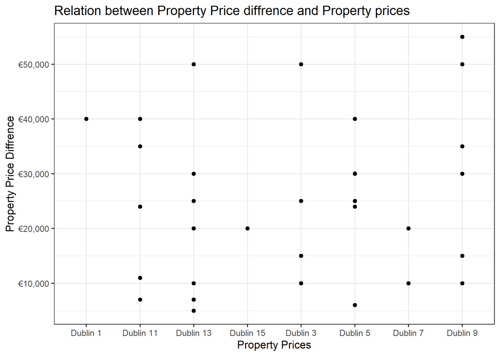

```r
df2%>%
  filter(price_diff!=0)%>%
  ggplot(aes(y=price_diff, x=area)) +
    geom_point()+
     geom_abline() +
    scale_y_continuous(labels = dollar_format(suffix = "", prefix = "€")) +

    theme_bw() +
    labs(
      x = "Property Prices",
      y = "Property Price Diffrence",
      title = "Relation between Property Price diffrence and Property prices"
    )
```

# Hypothesis 1

If price, number of bedroom, number of bathroom, area has an effect on the price changes.

```r
df2<-
  df2%>%
  filter(price_diff!=0)



mod_fit1<-lm(data=df2, price_diff~.)

summary(mod_fit1)
```

```
##
## Call:
## lm(formula = price_diff ~ ., data = df2)
##
## Residuals:
##      Min       1Q   Median       3Q      Max
## -18417.2  -4679.3   -755.8   5193.5  29052.8
##
## Coefficients: (1 not defined because of singularities)
##                    Estimate    Std. Error t value             Pr(>|t|)
## (Intercept)    16770.279148   6722.746346   2.495             0.012704 *
## price_parsed       0.024839      0.002079  11.949 < 0.0000000000000002 ***
## bedroom3        6466.930746    982.759322   6.580      0.0000000000619 ***
## bedroom4       21464.661967   1259.437597  17.043 < 0.0000000000000002 ***
## bedroom5       13042.876114   1346.738509   9.685 < 0.0000000000000002 ***
## bedroom10     -17831.470516   1909.140135  -9.340 < 0.0000000000000002 ***
## bathroom2       1741.729537    551.309208   3.159             0.001609 **
## bathroom3     -17198.870908    962.587695 -17.867 < 0.0000000000000002 ***
## bathroom4       9308.451484   1898.120533   4.904      0.0000010264172 ***
## bathroom5                NA            NA      NA                   NA
## areaDublin 11  -9028.129719   6683.220402  -1.351             0.176914
## areaDublin 13 -23228.613692   6707.982735  -3.463             0.000547 ***
## areaDublin 15 -34261.472285   7528.606767  -4.551      0.0000057134744 ***
## areaDublin 3  -10213.695936   6719.838125  -1.520             0.128710
## areaDublin 5  -10220.727518   6681.167030  -1.530             0.126253
## areaDublin 7  -20604.597097   6728.447234  -3.062             0.002230 **
## areaDublin 9   -8842.988555   6708.041100  -1.318             0.187588
## ---
## Signif. codes:  0 '***' 0.001 '**' 0.01 '*' 0.05 '.' 0.1 ' ' 1
##
## Residual standard error: 9337 on 1739 degrees of freedom
## Multiple R-squared:  0.6052, Adjusted R-squared:  0.6017
## F-statistic: 177.7 on 15 and 1739 DF,  p-value: < 0.00000000000000022
```

# Hypothesis 2

```r
df3<- daftdiff %>%
  select(price_diff,price_parsed, bedroom,bathroom,area_parsed) %>%
  mutate_at(vars(area_parsed),  ~ if_else(is.na(.), 0 , .)) %>%
   filter(price_diff!=0)


mod_fit2<-lm(data=df3, price_diff~.)

summary(mod_fit2)
```

```
##
## Call:
## lm(formula = price_diff ~ ., data = df3)
##
## Residuals:
##    Min     1Q Median     3Q    Max
## -19920  -9586  -2899   9563  35613
##
## Coefficients:
##                  Estimate   Std. Error t value             Pr(>|t|)
## (Intercept)  15686.617277  1285.203442  12.206 < 0.0000000000000002 ***
## price_parsed     0.052531     0.002292  22.919 < 0.0000000000000002 ***
## bedroom       -752.248542   330.120165  -2.279               0.0228 *
## bathroom     -4531.549941   472.734687  -9.586 < 0.0000000000000002 ***
## area_parsed   -636.550076    86.643854  -7.347     0.00000000000031 ***
## ---
## Signif. codes:  0 '***' 0.001 '**' 0.01 '*' 0.05 '.' 0.1 ' ' 1
##
## Residual standard error: 12700 on 1750 degrees of freedom
## Multiple R-squared:  0.2646, Adjusted R-squared:  0.2629
## F-statistic: 157.4 on 4 and 1750 DF,  p-value: < 0.00000000000000022
```

# Hypothesis 3

```r
mod_fit3<-lm(data=df2, price_diff~bathroom*bedroom*area*price_parsed)

summary(mod_fit3)
```

```
##
## Call:
## lm(formula = price_diff ~ bathroom * bedroom * area * price_parsed,
##     data = df2)
##
## Residuals:
##    Min     1Q Median     3Q    Max
## -25571      0      0      0  16326
##
## Coefficients: (340 not defined because of singularities)
##                                                                Estimate
## (Intercept)                                     257022.0890155915985815
## bathroom2                                      -237771.8314087763428688
## bathroom3                                       -15000.0000001270218490
## bathroom4                                        -3749.7423884530739997
## bathroom5                                       -22999.9999957289801387
## bedroom3                                          1250.2576118883721392
## bedroom4                                         17000.0000045400192903
## bedroom5                                         20749.7423930962286249
## bedroom10                                                            NA
## areaDublin 11                                  -246022.0890156847017352
## areaDublin 13                                  -274780.1958719451795332
## areaDublin 15                                    26657.3357503734587226
## areaDublin 3                                   -224022.0890202908485662
## areaDublin 5                                   -267138.9388447672827169
## areaDublin 7                                   -248272.3466275675746147
## areaDublin 9                                   -224022.0890200610447209
## price_parsed                                        -0.6237320550345621
## bathroom2:bedroom3                                8749.7423883816609305
## bathroom3:bedroom3                                                   NA
## bathroom4:bedroom3                                                   NA
## bathroom5:bedroom3                                                   NA
## bathroom2:bedroom4                               -1250.2576113978443573
## bathroom3:bedroom4                                                   NA
## bathroom4:bedroom4                                5348.9722873408518353
## bathroom5:bedroom4                                                   NA
## bathroom2:bedroom5                                                   NA
## bathroom3:bedroom5                                                   NA
## bathroom4:bedroom5                                                   NA
## bathroom5:bedroom5                                                   NA
```

[output cut: 1164 more lines]

```
## bathroom5:bedroom4:areaDublin 9:price_parsed            NA
## bathroom2:bedroom5:areaDublin 9:price_parsed            NA
## bathroom3:bedroom5:areaDublin 9:price_parsed            NA
## bathroom4:bedroom5:areaDublin 9:price_parsed            NA
## bathroom5:bedroom5:areaDublin 9:price_parsed            NA
## bathroom2:bedroom10:areaDublin 9:price_parsed           NA
## bathroom3:bedroom10:areaDublin 9:price_parsed           NA
## bathroom4:bedroom10:areaDublin 9:price_parsed           NA
## bathroom5:bedroom10:areaDublin 9:price_parsed           NA
## ---
## Signif. codes:  0 '***' 0.001 '**' 0.01 '*' 0.05 '.' 0.1 ' ' 1
##
## Residual standard error: 4535 on 1695 degrees of freedom
## Multiple R-squared:  0.9092, Adjusted R-squared:  0.906
## F-statistic: 287.7 on 59 and 1695 DF,  p-value: < 0.00000000000000022
```

# Hypothesis 4

```r
mod_fit4<-lm(data=df3, price_diff~bathroom*bedroom*area_parsed*price_parsed)

summary(mod_fit4)
```

```
##
## Call:
## lm(formula = price_diff ~ bathroom * bedroom * area_parsed *
##     price_parsed, data = df3)
##
## Residuals:
##    Min     1Q Median     3Q    Max
## -18660  -5884  -2028   2192  35122
##
## Coefficients:
##                                                  Estimate      Std. Error
## (Intercept)                               -501126.3470234   36414.8958479
## bathroom                                   185208.4229468   16699.3196972
## bedroom                                    182828.7774851   11839.9635829
## area_parsed                                 42260.4910476    3409.0045809
## price_parsed                                    0.7533223       0.0599822
## bathroom:bedroom                           -69221.6408780    4838.8902271
## bathroom:area_parsed                       -11703.8973475    1640.0466051
## bedroom:area_parsed                        -13953.3392851    1086.5419692
## bathroom:price_parsed                          -0.2251159       0.0202367
## bedroom:price_parsed                           -0.2622548       0.0195523
## area_parsed:price_parsed                       -0.0839133       0.0062052
## bathroom:bedroom:area_parsed                 4296.8989114     451.7499293
## bathroom:bedroom:price_parsed                   0.0892303       0.0061712
## bathroom:area_parsed:price_parsed               0.0197721       0.0019766
## bedroom:area_parsed:price_parsed                0.0261635       0.0018939
## bathroom:bedroom:area_parsed:price_parsed      -0.0069546       0.0005704
##                                           t value             Pr(>|t|)
## (Intercept)                               -13.762 < 0.0000000000000002 ***
## bathroom                                   11.091 < 0.0000000000000002 ***
## bedroom                                    15.442 < 0.0000000000000002 ***
## area_parsed                                12.397 < 0.0000000000000002 ***
## price_parsed                               12.559 < 0.0000000000000002 ***
## bathroom:bedroom                          -14.305 < 0.0000000000000002 ***
## bathroom:area_parsed                       -7.136      0.0000000000014 ***
## bedroom:area_parsed                       -12.842 < 0.0000000000000002 ***
## bathroom:price_parsed                     -11.124 < 0.0000000000000002 ***
## bedroom:price_parsed                      -13.413 < 0.0000000000000002 ***
## area_parsed:price_parsed                  -13.523 < 0.0000000000000002 ***
## bathroom:bedroom:area_parsed                9.512 < 0.0000000000000002 ***
## bathroom:bedroom:price_parsed              14.459 < 0.0000000000000002 ***
## bathroom:area_parsed:price_parsed          10.003 < 0.0000000000000002 ***
## bedroom:area_parsed:price_parsed           13.815 < 0.0000000000000002 ***
## bathroom:bedroom:area_parsed:price_parsed -12.193 < 0.0000000000000002 ***
## ---
## Signif. codes:  0 '***' 0.001 '**' 0.01 '*' 0.05 '.' 0.1 ' ' 1
##
## Residual standard error: 9630 on 1739 degrees of freedom
## Multiple R-squared:  0.5799, Adjusted R-squared:  0.5763
## F-statistic:   160 on 15 and 1739 DF,  p-value: < 0.00000000000000022
```